# ADM_Assignment1

# Q3. How many attributes remain in the model if lambda is set to 0.01? How that number changes if lambda is increased to 0.1? Do you expect more variables to stay in the model (i.e., to have non-zero coefficients) as we increase lambda?

```r
# View the coefficients at different lambda values
print(coefficients(Lasso_model, s=0.01))
```

```
## 7 x 1 sparse Matrix of class "dgCMatrix"
##                        s1
## (Intercept) 15.8946432052
## Price       -0.0571806037
## Advertising  0.1245169280
## Population  -0.0008863179
## Age         -0.0486751305
## Income       0.0103378849
## Education   -0.0347353427
```

```r
print(coefficients(Lasso_model, s=0.1))
```

```
## 7 x 1 sparse Matrix of class "dgCMatrix"
##                        s1
## (Intercept) 15.8946432052
## Price       -0.0571806037
## Advertising  0.1245169280
## Population  -0.0008863179
## Age         -0.0486751305
## Income       0.0103378849
## Education   -0.0347353427
```

[figure not shown]

```r
# Plot the coefficients as a function of lambda
plot(Lasso_model)
```

```r
#After the comparison between changing the lambda(0.01,0.1) value shows that all the attributes remains constant  in the model, even after changing the lambda values.
```

#Q4.Build an elastic-net model with alpha set to 0.6. What is the best value of lambda for such a model?

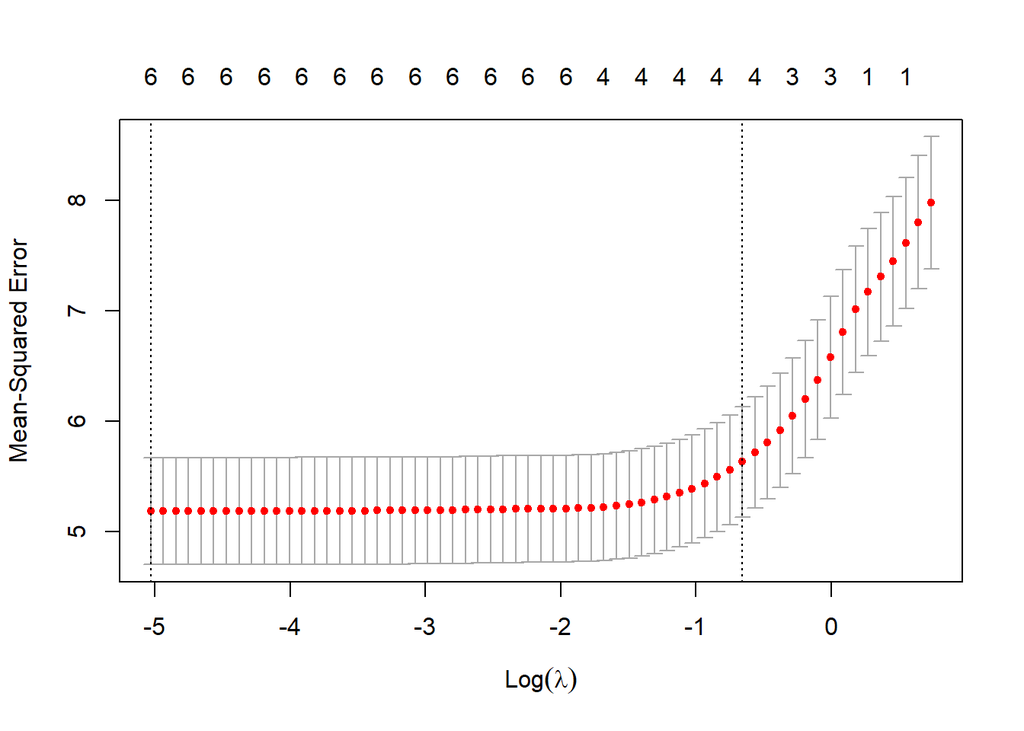

```r
# Build Elastic Net model with alpha = 0.6
Elastic_net_model <- cv.glmnet(X, y, alpha = 0.6)

# Plot the cross-validated mean squared error (optional)
plot(Elastic_net_model)
```

```r
# Find the best value of lambda
best_lambda_Elastic_net <- Elastic_net_model$lambda.min
cat("Best lambda value for Elastic Net model with alpha = 0.6:", best_lambda_Elastic_net, "\n")
```

```
## Best lambda value for Elastic Net model with alpha = 0.6: 0.006538062
```

```r
#The best value for Elastic_net_model with alpha 0.6 is:- 0.006538062
```